# Weather

## Introduction

In this analysis, we investigate the relationship between the daily minimum temperature (MIN) and the daily maximum temperature (MAX) for two weather stations: one in Rexburg and one in Salt Lake City. The motivation is to understand how well the daily (MIN) temperature predicts the daily (MAX) temperature and to see if the relationship differs between the two locations. To accomplish this, we use the **GSODR** package to retrieve weather data for the year 2021, perform a multiple linear regression analysis, and visually inspect the model with various plots.

## Setup and Data Acquisition

```r
# Load necessary packages
library(GSODR)  # Ensure this package is installed (install.packages("GSODR") if needed)
library(dplyr)
library(ggplot2)
library(car)
library(DT)
library(tidyr)
library(mosaic)
library(pander)

# Load additional data if needed (isd_history might help to identify stations)
data("isd_history")

# Choose two weather stations
# For example: Rexburg -- STNID = "726818-94194" and Salt Lake City -- STNID = "725720-24127"

# Download data for 2021
Rexburg <- get_GSOD(years = 2021, station = "726818-94194")
Salt_Lake <- get_GSOD(years = 2021, station = "725720-24127")

# Review downloaded data if desired
# View(Rexburg)
# View(Salt_Lake)

# Combine the two datasets
weather <- rbind(Rexburg, Salt_Lake)

# Select only the relevant columns for the analysis: station NAME, MAX, and MIN temperatures
weather2 <- weather %>% select(NAME, MAX, MIN)

# Optional: show table preview
datatable(weather2, options = list(pageLength = 5))
```

|  | NAME | MAX | MIN |
| --- | --- | --- | --- |
| 1 | REXBURG-MADISON COUNTY APT | -2.2 | -8.3 |
| 2 | REXBURG-MADISON COUNTY APT | -2.8 | -6.1 |
| 3 | REXBURG-MADISON COUNTY APT | 0.6 | -6.1 |
| 4 | REXBURG-MADISON COUNTY APT | 1.1 | -8.3 |
| 5 | REXBURG-MADISON COUNTY APT | 2.8 | -8.3 |
| 6 | REXBURG-MADISON COUNTY APT | 2.2 | -10.6 |
| 7 | REXBURG-MADISON COUNTY APT | -1 | -9.4 |
| 8 | REXBURG-MADISON COUNTY APT | 0 | -8.3 |
| 9 | REXBURG-MADISON COUNTY APT | 0 | -17.2 |
| 10 | REXBURG-MADISON COUNTY APT | -5 | -17.2 |

[output cut: 720 more lines]

## Graphical Summary

We now create a scatter plot of MIN versus MAX colored by station name. A linear regression line is added for each group to visually assess the relationship. This plot gives an initial overview of the linear association between the minimum and maximum temperatures for each city.

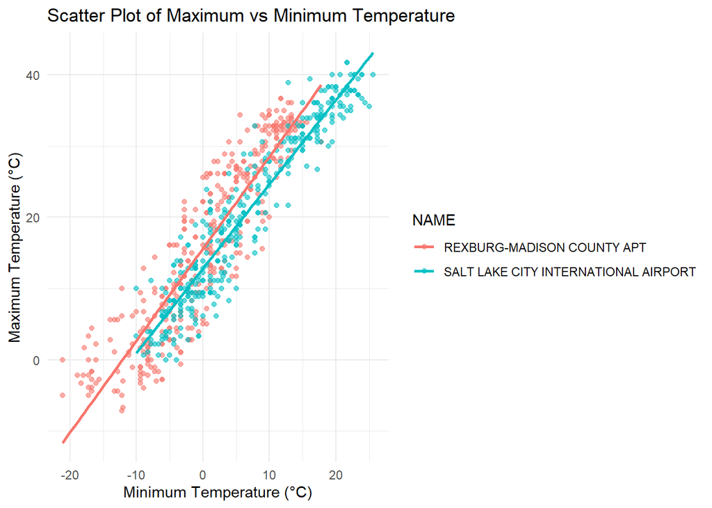

```r
# Scatter plot with separate regression lines for each station
ggplot(weather2, aes(x = MIN, y = MAX, color = NAME)) +
 geom_point(alpha = 0.6) +
 geom_smooth(method = 'lm', se = FALSE) +
 labs(title = 'Scatter Plot of Maximum vs Minimum Temperature',
      x = 'Minimum Temperature (°C)',
      y = 'Maximum Temperature (°C)') +
 theme_minimal()
```

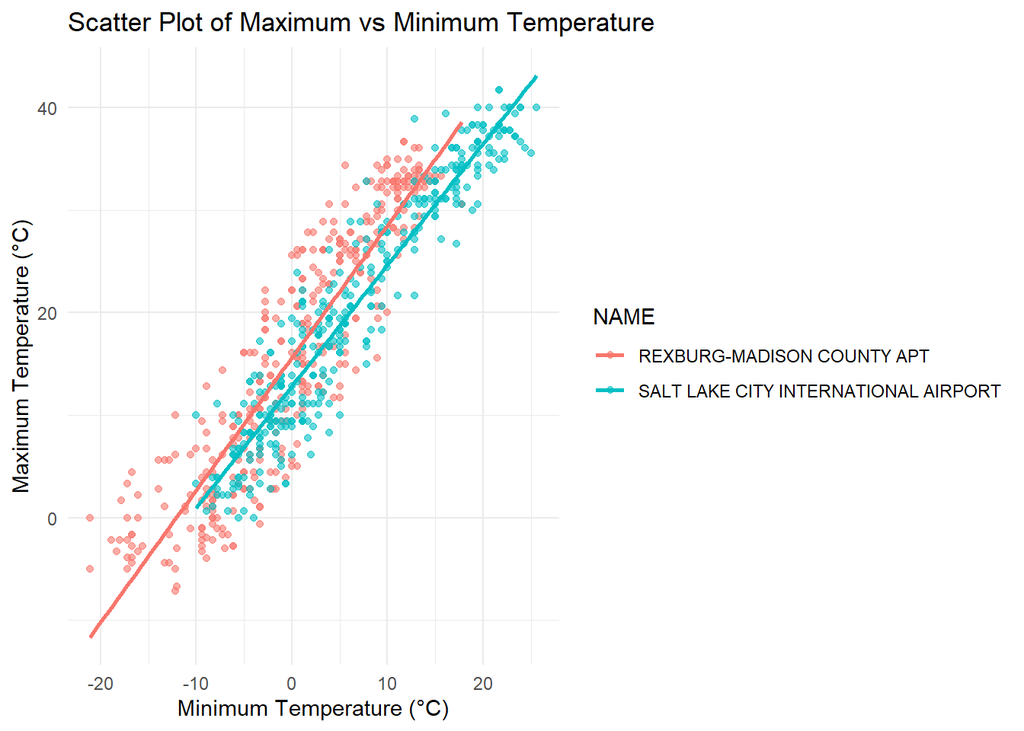

```r
# Scatter plot with separate regression lines for each station
ggplot(weather2, aes(x = MIN, y = MAX, color = NAME)) +
 geom_point(alpha = 0.6) +
 geom_smooth(method = 'lm', se = FALSE) +
 labs(title = 'Scatter Plot of Maximum vs Minimum Temperature',
      x = 'Minimum Temperature (°C)',
      y = 'Maximum Temperature (°C)') +
 theme_minimal()
```

## Numerical Summary: Multiple Linear Regression

Next, we fit a multiple linear regression model predicting MAX as a function of MIN and the station (represented by NAME). This allows us to evaluate both the overall effect of MIN and potential differences between the two locations.

```r
# Fit the multiple linear regression model
weather_lm <- lm(MAX ~ MIN + NAME, data = weather2)

# Summary of the regression model
pander(summary(weather_lm))
```

|  | Estimate | Std. Error | t value | Pr(>\|t\|) |
| --- | --- | --- | --- | --- |
| **(Intercept)** | 15.63 | 0.2379 | 65.69 | 6.01e-308 |
| **MIN** | 1.235 | 0.01879 | 65.75 | 3.227e-308 |
| **NAMESALT LAKE CITY INTERNATIONAL AIRPORT** | -3.143 | 0.3574 | -8.794 | 1.035e-17 |

Fitting linear model: MAX ~ MIN + NAME

| Observations | Residual Std. Error | $R^2$ | Adjusted $R^2$ |
| --- | --- | --- | --- |
| 730 | 4.544 | 0.8617 | 0.8613 |

The output of the regression summary will indicate the estimated coefficients, standard errors, t-statistics, and p-values for each predictor. This helps us understand the significance and magnitude of the relationship between MIN and MAX across the two cities.

## Diagnostic Plots for Model Requirements

To evaluate if the assumptions of the linear regression model are satisfied, we generate several diagnostic plots. These include:

**Residuals vs Fitted Plot:** Checks for issues with non-linearity and unequal variance. **Normal Q-Q Plot:** Assesses normality of the residuals. **Scale-Location Plot:** Verifies homoscedasticity. **Residuals vs Leverage Plot:** Identifies influential observations.

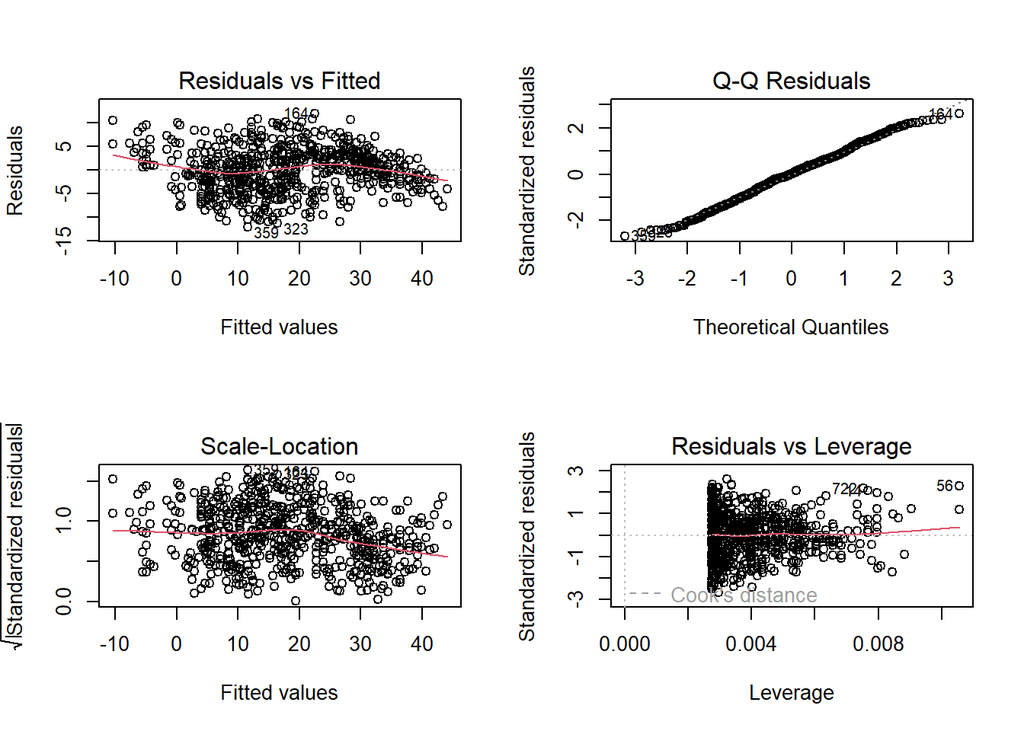

```r
# Diagnostic plots
par(mfrow = c(2,2))
plot(weather_lm)
```

Additionally, an added variable plot is used to show the contribution of the MIN variable after accounting for the effect of NAME.

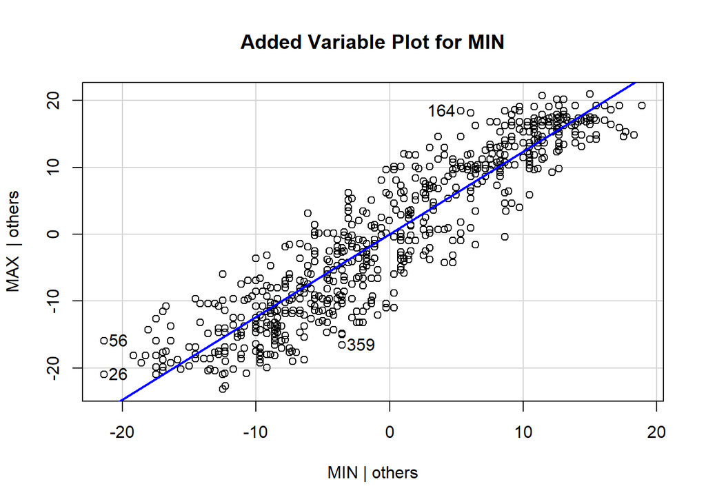

```r
# Added variable plot for MIN
avPlot(weather_lm, variable = 'MIN', main = 'Added Variable Plot for MIN')
```

Conclusion and Interpretation Based on the regression results, we can draw several important conclusions about the relationship between minimum and maximum temperatures across the two weather stations.

The multiple linear regression model (MAX ~ MIN + NAME) demonstrates a strong relationship between the variables, with an adjusted R-squared value of 0.8613. This indicates that approximately 86.13% of the variation in maximum temperature can be explained by the minimum temperature and the station location, which represents an excellent fit for weather data.

Looking at the specific coefficients:

The intercept (15.63°C) represents the expected maximum temperature in Rexburg when the minimum temperature is 0°C. This baseline is statistically significant (p < 6.01e-308).

The coefficient for MIN (1.235) indicates that for each 1°C increase in minimum temperature, we expect the maximum temperature to increase by approximately 1.235°C, holding the location constant. This relationship is highly significant (p < 3.227e-308).

The coefficient for NAME (SALT LAKE CITY INTERNATIONAL AIRPORT) is -3.143, which means that Salt Lake City’s maximum temperatures are, on average, 3.143°C lower than Rexburg’s when controlling for the same minimum temperature. This difference is statistically significant (p < 1.035e-17).

The residual standard error of 4.544°C represents the average deviation of observed maximum temperatures from the predicted values. While this indicates some variability not captured by our model, the high R-squared value suggests that the model is still quite effective at predicting maximum temperatures.

In practical terms, these results suggest that Rexburg experiences more extreme temperature swings from minimum to maximum compared to Salt Lake City. This could be attributed to various geographical factors such as elevation, proximity to water bodies, or urban heat island effects. The strong predictive power of minimum temperature across both locations highlights its utility as a forecasting tool for daily maximum temperatures.